# summary

Shi Aohua

2017年11月24日

# Homework Explanations

## homework3

### problem1 : the 6th question

Answer: substitutes.

Because the price of good2 rises, p1 increases with q1 = 1000-10p1 +

5p2 + 2I, then q1 increases, which is in good agreement with good1 and

good2 being substitutes. If it is complementary, then p2 increased, q1

should be reduced.

### problem2: the 3th question

Answer：We cannot conclude definitely whether food is normal or inferior.

Because we draw the horizontal axis of the data as income, the

vertical axis for food expenditure. According to the definition of

normal good, when the income increases, the number of purchased goods

should be increased. What we can draw from the picture is that when

income increases, food expenditure increases, ie P * Q. When the good

is inferior, it is also possible to draw such an image (for example,

the quantity of Inferior good has not changed and its price has

risen), so we can not judge it.

### problem3: the 6th question

Stressed a bit When studying the relationship between oil and corn price

changes, the need to control other factors unchanged. Otherwise, other

factors, such as income changes, can have an impact on the result.

## homework4

Part1 Answer to the first question:C.

a: Long-term flexibility is stronger than short-term

b: smoke alarm is required, the Persian rug is a luxury

c: correct.

Answer to the second question B

teaching assistant to explain arc price elasticity (two points) and point

price elasticity (a point)

Answer to the third question B

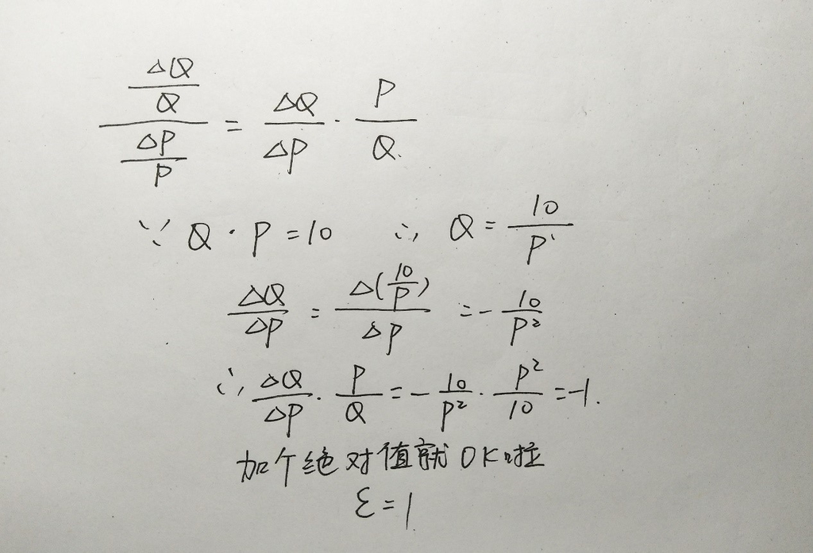

show1

Answer to the fourth question:C

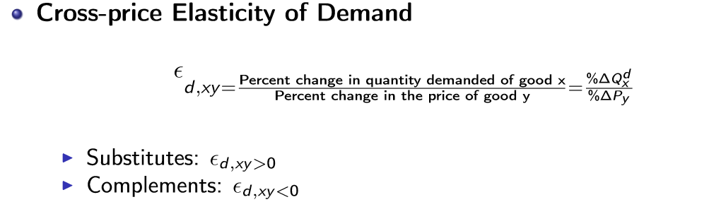

show2

Let’s review the arc elasticity and point elasticity.

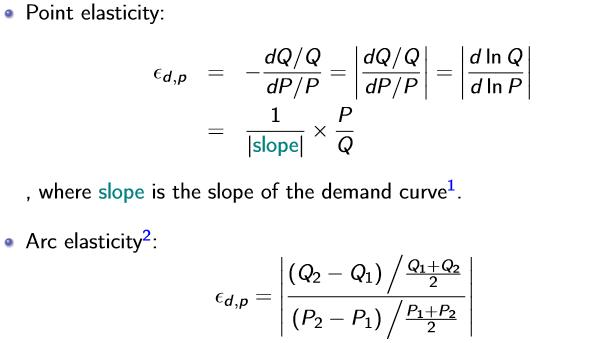

show

Part2 roughly explain a bit, based on the answers you can understand.

# Courseware Explanations

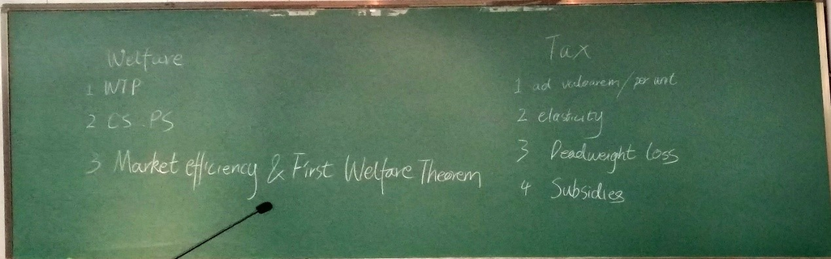

Assistant’s blackboard writing

contents are as follows:

1:WTP that is willing to pay, is the price you are willing to pay.

2:CS: consumer surplus consumer surplus. PS: producer surplus producer

surplus.If you go to the supermarket to buy things, the expected price is

10 yuan, the supermarket sells 5 yuan, then CS is 10-5 = 5 yuan. PS is to

buy the price higher than the price of production, then the surplus is the

price minus the cost of production.

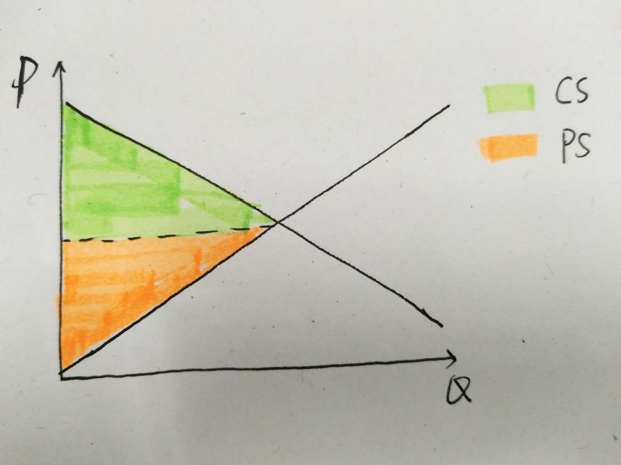

show

If the costs of inputs for A fall, then the curve should be:

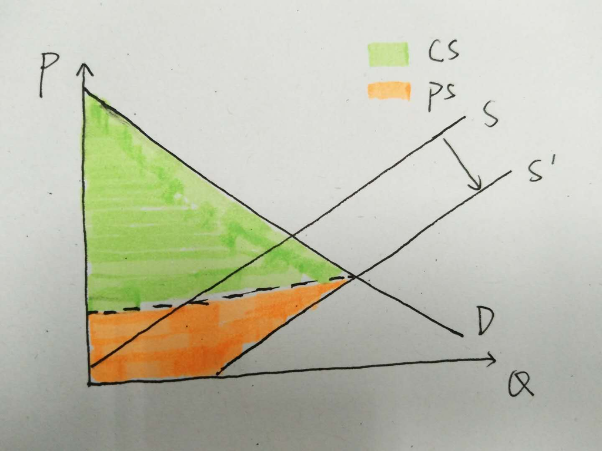

show

And so on……

3:Market efficient market effectiveness (assistant cited the market

economy and planned economy example shows that the market economy can be

more effective in accordance with the needs of the market to produce

products, and the planned economy often fail to such an effect can not be

effectively controlled produce)

First welfare theory. Inside the effective market. Everyone to do good

things for themselves, will bring good benefits to the market, the effect of

selfless than everyone else for the community want to be better. At the same

time pointed out that this is just a theory. Not absolutely correct.

4:Tax revenue is divided into two types, one is ad valorem, one is per unit

(at this time draw the graph and the teacher drawing roughly the same).

5:before talking about the elasticity of goods, now tax is about demand and

supply elasticity. If the demand for the elasticity of demand is bigger,

then the tax is assigned to the supply; if the elasticity of the supply is

relatively large, then the tax is on the demand.

6:Deadweight Loss

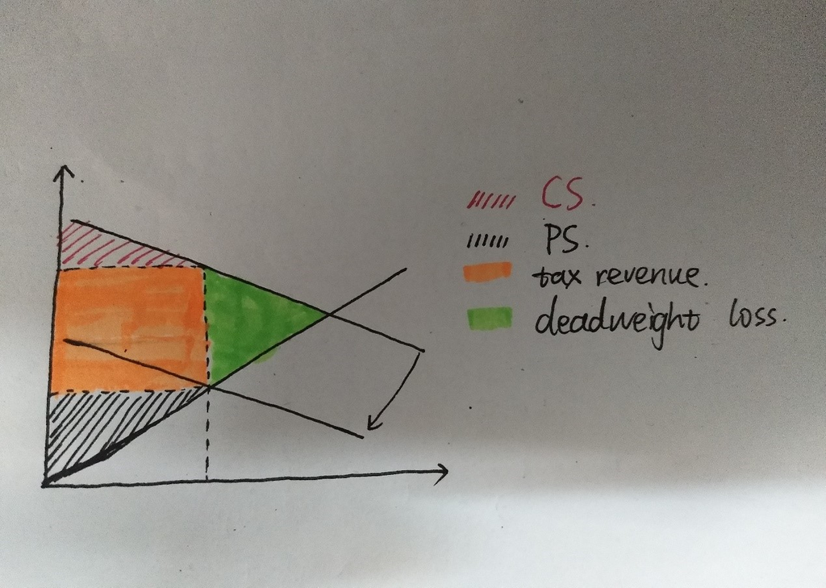

show4

[figure not shown]

show

7:Subsidy briefly introduced the allowance, specifically to see courseware

or notes.

# the usage of rstudio(the problem5 in homework5)

the first question: draw a demand curve

```
Stroke rooting sqrt () Or you can square the sides of the formula,

remove the root number.
```

the second question:

```
Talking about the price will fluctuate around the value, talked about

the meaning of volatility. Then talked about The Simplest Introduction

to Regression EVER (GitHub above) normal distribution. As follows,

pointed out that the r language which defaults to the normal

distribution of N (0,1).
```

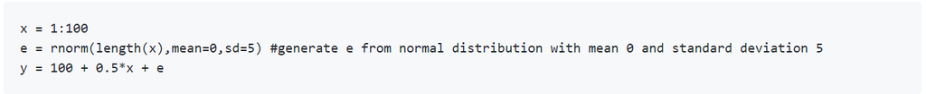

show5

```
Length (x) is the length of x, sd is the standard deviation.
```

the third question:Scatter plot, similar to the previous painting

the fourth question:

```
Define log (p) with a, etc., to define the new logarithm.

Note that the logarithm in r is written directly, nothing changes

Add fit line similar to before, did not detail.
```

the fifth question:

```
Find the fitting line slope

Github explained, see intro_regression

For example:
```

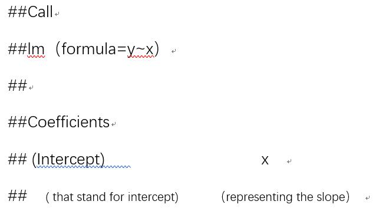

show6